# RP Differential Analysis

# 1. Importing Libraries

```r
library(tidyverse)
library(ggrepel)
library(ggsci)
library(pheatmap)
library(RColorBrewer)
library(readxl)
library(UpSetR)
source('functions_cdis_diff.R')
```

Change to what data you are using

```r
data= 'RP'
```

# 2. Import data

Because differential analysis includes the calculations of means, the data to be used in this section is the normalized untransformed data

```r
# set path variables
project_dir <- getwd()
project_name <- 'RP_Final_rem1177_2'
figures_dir <- file.path(project_dir, paste0(project_name, '_output_figures'))
tables_dir <- file.path(project_dir,  paste0(project_name, '_output_tables'))
norm_auc_table_file <- file.path(tables_dir, 'normalized_untransformed_auc_table.csv')

# If the flag was setted before, nothing needs to be changed here, the correct file will be automatically used

  compounds_table_file <- file.path(tables_dir, 'compounds_table.csv')


# Load auc_table

norm.matrix <- read_csv(norm_auc_table_file)
```

```
* `` -> ...1
```

```r
norm.matrix <- column_to_rownames(norm.matrix, var = '...1')

# Load compounds table and add a column that has names for identified compounds and FeatureID for the rest (for plotting puRPouses)

compounds_table <- read_csv(compounds_table_file)
# Import metadata and fix names
metadata_file <- file.path(tables_dir, 'fixed_metadata.csv')
metadata <- read_csv(metadata_file)
```

# 3. Calculate ratios and log2fold-change

## 3.1 Get samples per each treatment

```r
# Get the average AUC per each of the treatments
## Get samples per treatment

F1154.samples <- get_samples(metadata, Treatment = 'Fungi', value = '1154')
F1177.samples <- get_samples(metadata, Treatment = 'Fungi', value = '1177')
F1246.samples <- get_samples(metadata, Treatment = 'Fungi', value = '1246')
CTRL.samples <- get_samples(metadata, Treatment = 'Fungi', value = 'CTRL')
```

## 3.2 Get table of differentially expressed features per each comparison

The following function will calculate ratio, log2FC, p values and adjusted pvalues. If no replicates are available for EACH treatment please use the get_diff_table_no_pval() function

```r
# The following function will calculate ratio, log2FC, p values and adjusted pvalues. If no replicates are available for EACH treatment
# please use the get_diff_table_no_pval() function

F1154_to_CTRL.diff_table <- get_diff_table(norm.matrix, treatment.sample_list = F1154.samples, control.sample_list = CTRL.samples)
F1177_to_CTRL.diff_table <- get_diff_table(norm.matrix, treatment.sample_list = F1177.samples, control.sample_list = CTRL.samples)
F1246_to_CTRL.diff_table <- get_diff_table(norm.matrix, treatment.sample_list = F1246.samples, control.sample_list = CTRL.samples)
```

Merge differentially expressed features with the annotation

```r
# Create dataframes for the up and downregulated metabolites at each time point and merge them with the compound information

F1154_to_CTRL.diff_table <- compounds_table %>%
  select( - contains('Results'), -SampleID, -AUC,  -Fungi, - Plant) %>%
  right_join(F1154_to_CTRL.diff_table, by = 'FeatureID') %>%
  distinct() %>%
  filter(!is.nan(log2FC)) %>%
  mutate(Comment = case_when(log2FC == Inf ~ 'Not present in control',
                             log2FC == -Inf ~ 'Only present in control',
                             log2FC < 0 ~ 'Downregulated',
                             log2FC > 0 ~ 'Upregulated'))

F1154_to_CTRL.diff_table$Comment <- factor(F1154_to_CTRL.diff_table$Comment,
                               levels = c('Only present in control', 'Downregulated', 'Upregulated', 'Not present in control' ))

table_file <- file.path(tables_dir, 'Diff_expressed_F1154.csv')
write_csv(F1154_to_CTRL.diff_table, table_file )

F1177_to_CTRL.diff_table<- compounds_table %>%
  select(-contains('Annotation Source:'), - contains('Results'), -SampleID, -AUC, -Plant, - Fungi) %>%
  right_join(F1177_to_CTRL.diff_table, by = 'FeatureID') %>%
  distinct() %>%
  filter(!is.nan(log2FC)) %>%
  mutate(Comment = case_when(log2FC == Inf ~ 'Not present in control',
                             log2FC == -Inf ~ 'Only present in control',
                             log2FC < 0 ~ 'Downregulated',
                             log2FC > 0 ~ 'Upregulated'))

F1177_to_CTRL.diff_table$Comment <- factor(F1177_to_CTRL.diff_table$Comment,
                               levels = c('Only present in control', 'Downregulated', 'Upregulated', 'Not present in control' ))

table_file <- file.path(tables_dir, 'Diff_expressed_F1177.csv')
write_csv(F1177_to_CTRL.diff_table, table_file )

F1246_to_CTRL.diff_table <- compounds_table %>%
  select(-contains('Annotation Source:'), - contains('Results'), -SampleID, -AUC, -Plant, -Fungi) %>%
  right_join(F1246_to_CTRL.diff_table, by = 'FeatureID') %>%
  distinct() %>%
  filter(!is.nan(log2FC)) %>%
  mutate(Comment = case_when(log2FC == Inf ~ 'Not present in control',
                             log2FC == -Inf ~ 'Only present in control',
                             log2FC < 0 ~ 'Downregulated',
                             log2FC > 0 ~ 'Upregulated'))

F1246_to_CTRL.diff_table$Comment <- factor(F1246_to_CTRL.diff_table$Comment,
                               levels = c('Only present in control', 'Downregulated', 'Upregulated', 'Not present in control' ))

table_file <- file.path(tables_dir, 'Diff_expressed_F1246.csv')
write_csv(F1246_to_CTRL.diff_table, table_file )
```

Extract most differentially expressed features

```r
# Extract significant features of each comparison based on adjusted pvalue
sig_features <- c(F1154_to_CTRL.diff_table$FeatureID[F1154_to_CTRL.diff_table$pval.adj < 0.05],
                  F1177_to_CTRL.diff_table$FeatureID[F1177_to_CTRL.diff_table$pval.adj < 0.05],
                  F1246_to_CTRL.diff_table$FeatureID[F1246_to_CTRL.diff_table$pval.adj < 0.05])

sig_features <- unique(sig_features)
```

# 4. Plots of dysregulated features

## 4.1 Number of dysregulated features in each group

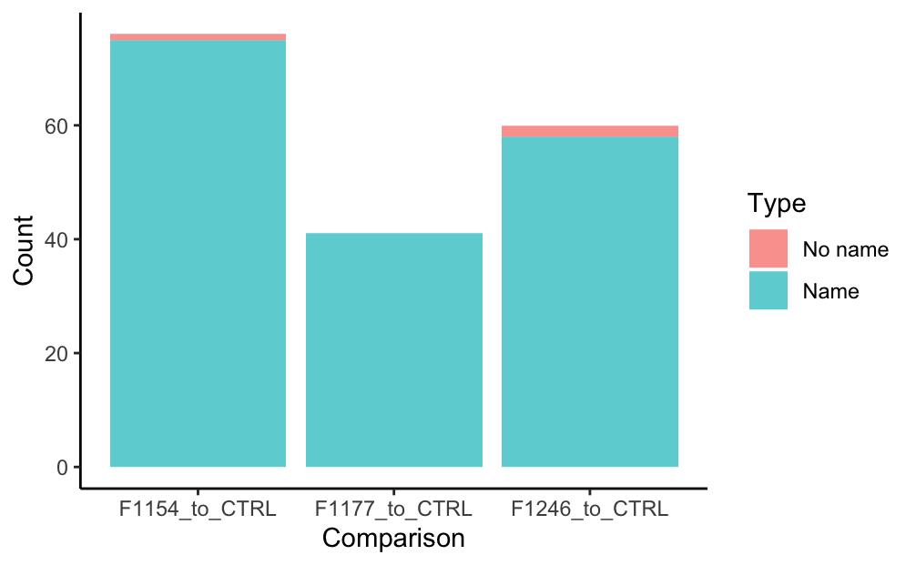

```r
# removed pval adj to regular pval
num_diff_features <- tibble(Comparison = rep(c('F1154_to_CTRL', 'F1177_to_CTRL', 'F1246_to_CTRL'), each = 2),
                            Type = rep(c('Name', 'No name'), 3),
                            count = 0)
num_diff_features$Type <- factor(num_diff_features$Type, levels = c('No name', 'Name'))

num_diff_features[1, 3] <- sum(F1154_to_CTRL.diff_table$pval.adj < 0.05 & !is.na(F1154_to_CTRL.diff_table$Name), na.rm = TRUE)
num_diff_features[2, 3] <- sum(F1154_to_CTRL.diff_table$pval.adj < 0.05 & is.na(F1154_to_CTRL.diff_table$Name), na.rm = TRUE)
num_diff_features[3, 3] <- sum(F1177_to_CTRL.diff_table$pval.adj < 0.05 & !is.na(F1177_to_CTRL.diff_table$Name), na.rm = TRUE)
num_diff_features[4, 3] <- sum(F1177_to_CTRL.diff_table$pval.adj < 0.05 & is.na(F1177_to_CTRL.diff_table$Name), na.rm = TRUE)
num_diff_features[5, 3] <- sum(F1246_to_CTRL.diff_table$pval.adj < 0.05 & !is.na(F1246_to_CTRL.diff_table$Name), na.rm = TRUE)
num_diff_features[6, 3] <- sum(F1246_to_CTRL.diff_table$pval.adj < 0.05 & is.na(F1246_to_CTRL.diff_table$Name), na.rm = TRUE)


num_diff_plot <- ggplot(num_diff_features)+
  geom_bar(aes(y=count, x=Comparison,fill= Type), stat="identity", alpha=0.7)+
  theme_classic()+xlab("Comparison")+ylab("Count")

num_diff_plot
# shows snumber of significantly regulated compounds
figure_file <- file.path(figures_dir, 'Num_diff_features.png')
ggsave(figure_file, num_diff_plot, dpi = 300)
```